# General Mills Cereal Sales Analysis

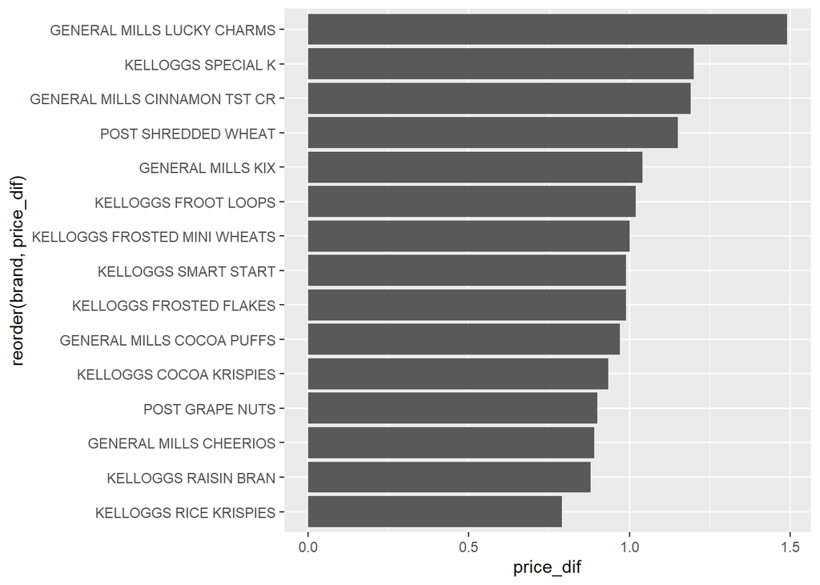

```r
#do similar but with delta price
full_df %>%
  group_by(brand, promo) %>%
  summarize(med_price = median(price)) %>%
  spread(promo, med_price, sep = '_') %>%
  mutate(price_dif = promo_0 - promo_1) %>%
  ggplot(mapping = aes(x = reorder(brand,price_dif), y = price_dif)) +
  geom_bar(stat = 'identity') +
  coord_flip()
```

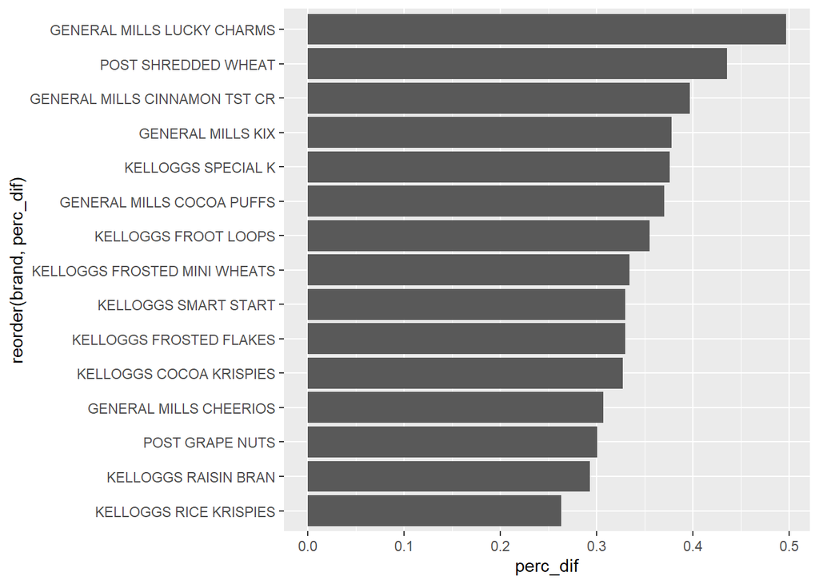

```r
full_df %>%
  group_by(brand, promo) %>%
  summarize(med_price = median(price)) %>%
  spread(promo, med_price, sep = '_') %>%
  mutate(perc_dif = promo_0 / promo_1 - 1) %>%
  ggplot(mapping = aes(x = reorder(brand,perc_dif), y = perc_dif)) +
  geom_bar(stat = 'identity') +
  coord_flip()
```

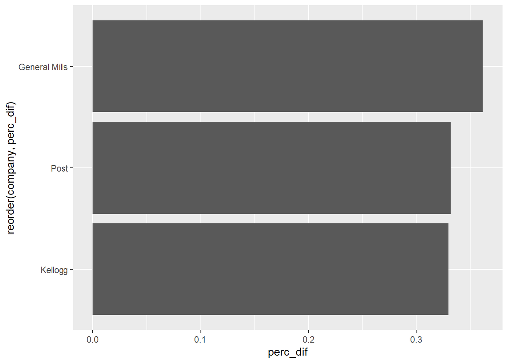

```r
#similar but by company
full_df %>%
  group_by(company, promo) %>%
  summarize(med_price = median(price)) %>%
  spread(promo, med_price, sep = '_') %>%
  mutate(perc_dif = promo_0 / promo_1 - 1) %>%
  ggplot(mapping = aes(x = reorder(company,perc_dif), y = perc_dif)) +
  geom_bar(stat = 'identity') +
  coord_flip()
```

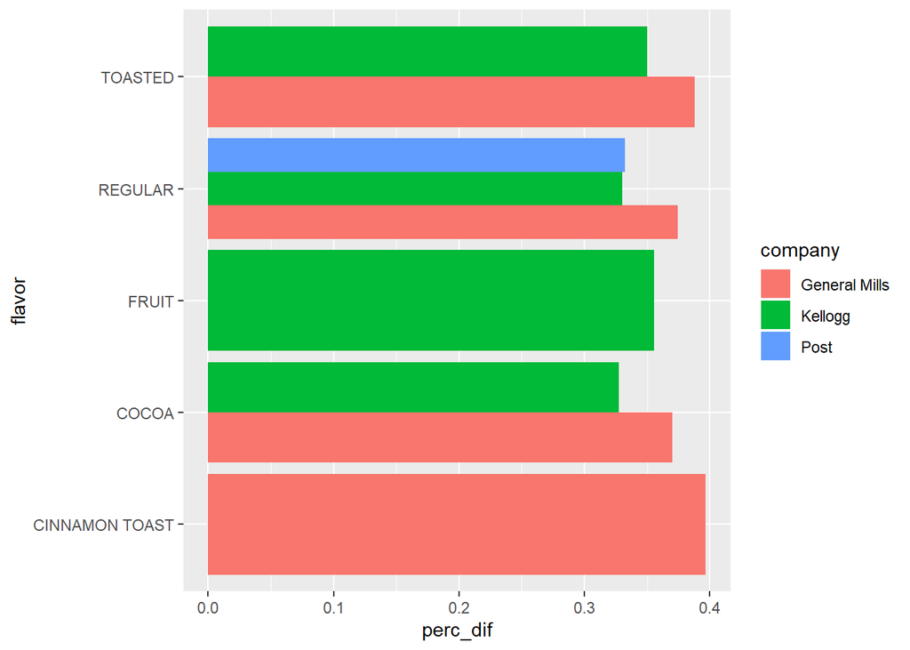

```r
full_df %>%
  group_by(flavor, company, promo) %>%
  summarize(med_price = median(price)) %>%
  spread(promo, med_price, sep = '_') %>%
  mutate(perc_dif = promo_0 / promo_1 - 1) %>%
  ggplot(mapping = aes(x = flavor, y = perc_dif, fill = company)) +
  geom_bar(stat = 'identity', position = 'dodge') +
  coord_flip()
```

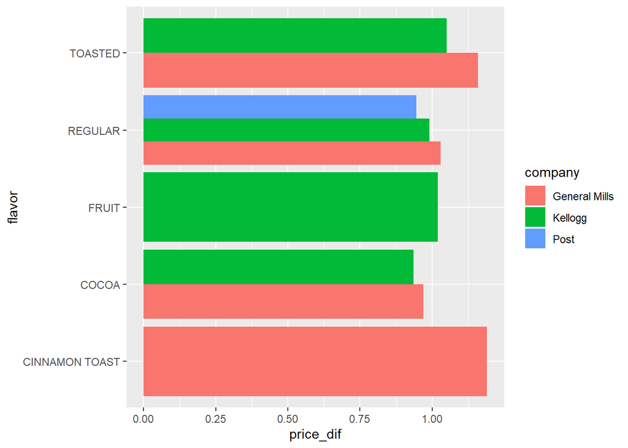

```r
full_df %>%
  group_by(flavor, company, promo) %>%
  summarize(med_price = median(price)) %>%
  spread(promo, med_price, sep = '_') %>%
  mutate(price_dif = promo_0 - promo_1) %>%
  ggplot(mapping = aes(x = flavor, y = price_dif, fill = company)) +
  geom_bar(stat = 'identity', position = 'dodge') +
  coord_flip()
```

```r
#test price difference significance
#first filter arrays for setting up t-test data frames
kellogg_promos <- full_df %>% filter(promo == 1, company == 'Kellogg')
kellogg_norm   <- full_df %>% filter(promo == 0, company == 'Kellogg')

gm_promos <- full_df %>% filter(promo == 1, company == 'General Mills')
gm_norm <- full_df %>% filter(promo == 0, company == 'General Mills')

#calculate promo price below mean
#do per upc and store avgs
# kellogg_mean_prices <- kellogg_norm %>%
#   group_by(UPC, store_key) %>%
#   summarize(avg_yrly_price = mean(price))
#
# kellogg_promos <- left_join(kellogg_promos, kellogg_mean_prices, by = c('UPC', 'store_key')) %>%
#   mutate(price_dif = avg_yrly_price - price,
#          perc_disc = 1 - price / avg_yrly_price) %>%
#   na.omit()
#
# gm_mean_prices <- gm_norm %>%
#   group_by(UPC, store_key) %>%
#   summarize(avg_yrly_price = mean(price))
#
# gm_promos <- left_join(gm_promos, gm_mean_prices, by = c('UPC', 'store_key')) %>%
#   mutate(price_dif = avg_yrly_price - price,
#          perc_disc = 1 - price / avg_yrly_price) %>%
#   na.omit()
#
# #quite a few zeros or negative discounts (~10%) skewing data
# kellogg_promos_gt_0 <- kellogg_promos %>% filter(price_dif > 0)
# gm_promos_gt_0 <- gm_promos %>% filter(price_dif > 0)

t.test(gm_norm$price, kellogg_norm$price)
```

```
##
##  Welch Two Sample t-test
##
## data:  gm_norm$price and kellogg_norm$price
## t = 7.2688, df = 11428, p-value = 0.0000000000003864
## alternative hypothesis: true difference in means is not equal to 0
## 95 percent confidence interval:
##  0.08695999 0.15117909
## sample estimates:
## mean of x mean of y
##  4.056189  3.937119
```

```r
#better comparison is normalize for volume
t.test(gm_norm$price / gm_norm$volume, kellogg_norm$price / kellogg_norm$volume)
```

```
##
##  Welch Two Sample t-test
##
## data:  gm_norm$price/gm_norm$volume and kellogg_norm$price/kellogg_norm$volume
## t = 14.398, df = 14106, p-value < 0.00000000000000022
## alternative hypothesis: true difference in means is not equal to 0
## 95 percent confidence interval:
##  0.3256681 0.4283165
## sample estimates:
## mean of x mean of y
##  4.696031  4.319039
```

```r
t.test(gm_promos$price / gm_promos$volume, kellogg_promos$price / kellogg_promos$volume)
```

```
##
##  Welch Two Sample t-test
##
## data:  gm_promos$price/gm_promos$volume and kellogg_promos$price/kellogg_promos$volume
## t = 4.6993, df = 3060.4, p-value = 0.000002726
## alternative hypothesis: true difference in means is not equal to 0
## 95 percent confidence interval:
##  0.1451448 0.3529851
## sample estimates:
## mean of x mean of y
##  3.759158  3.510093
```

```r
#test percentage of sales from promos
kellogg_all <- full_df %>% filter(company =='Kellogg')
gm_all      <- full_df %>% filter(company == 'General Mills')

# t.test(kellogg_all$promo * kellogg_all$total_sales / , gm_all$promo * gm_all$total_sales)

# t.test(kellogg_promos_gt_0$price_dif, gm_promos_gt_0$price_dif)
```

# 8 Regression analysis

```r
# # Relevel brands to have brand with lowest sales as the base
# full_df$brand <- relevel(full_df$brand, ref = "KELLOGGS COCOA KRISPIES")
# # Relevel companies to have Post as the base
# full_df$company <- relevel(full_df$company, ref = "Post")
#
# # Model with brands only
# mod1 <- lm(total_sales ~ brand, data = full_df)
# summary(mod1)
# # Model with brands, ads, and promos
# mod2 <- lm(total_sales~ brand + promo + ad2, data = full_df)
# summary(mod2)
#
# # Model with brands, ads, and promos
# mod3 <- lm(price~ volume + promo + ad2 + brand, data = full_df)
# summary(mod3)
```

# 9 Conclusions and final visualizations

## 9.1 Finding #1: On average, Cheerios sales decrease with promotions

```r
# Set my theme to make visualizations consistent
my_theme <- theme(panel.border = element_blank(),
        panel.background = element_blank(),
        axis.ticks.y = element_line(color = "white"),
        axis.line.x = element_line(color = "gray"),
        axis.ticks.x = element_line(color = "gray"),
        plot.title = element_text(color = "#808080", size = 16, face = "bold"),
        plot.subtitle = element_text(color = "#808080", size = 12, face = "plain"),
        axis.text.x = element_text(color = "#808080", size = 11),
        axis.text.y = element_text(color = "#808080", size = 11),
        axis.title = element_text(color = "#808080", size = 11, face = "plain"),
        legend.title = element_text(color = "#808080", size = 12, face = "plain"),
        legend.text = element_text(color = "#808080", size = 12, face = "plain"),
        plot.caption = element_text(color = "#808080", size = 10, face = "plain", margin = margin(t=10))
        )
```

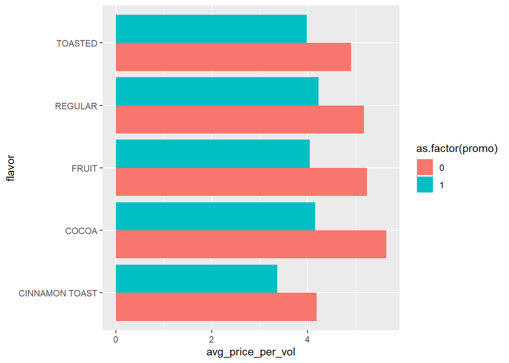

```r
#plot discount levels for GM vs Kellogg in competing flavors

full_df %>%
  group_by(flavor, company, promo) %>%
  summarize(avg_price_per_vol = mean(price / volume)) %>%
  ggplot(mapping = aes(x = flavor, y = avg_price_per_vol,
                       fill = as.factor(promo))) +
  geom_bar(stat = 'identity', position = 'dodge') +
  coord_flip()
```

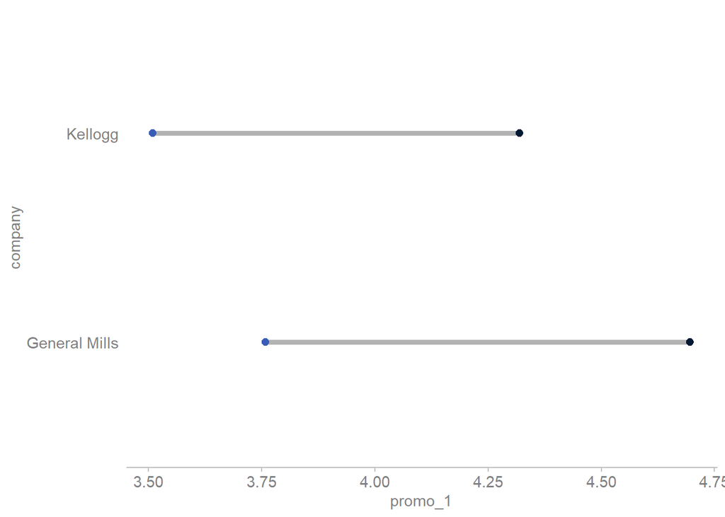

```r
#filter FRUIT because no GM brand in that flavor
kellogg_fig_df <- full_df %>%
  filter(company == 'Kellogg', flavor != 'FRUIT') %>%
  group_by(flavor, promo) %>%
  summarize(avg_price_per_vol = mean(price / volume)) %>%
  spread(promo, avg_price_per_vol, sep = '_')

#filter CINNAMON TOAST because no Kellogg brand in that flavor
gm_fig_df <- full_df %>%
  filter(company == 'General Mills', flavor != 'CINNAMON TOAST') %>%
  group_by(flavor, promo) %>%
  summarize(avg_price_per_vol = mean(price / volume)) %>%
  spread(promo, avg_price_per_vol, sep = '_')

# fig <- ggplot(kellogg_fig_df) +
#   geom_dumbbell(mapping = aes(y = flavor, x = promo_1, xend = promo_0)) +
#   geom_dumbbell(data = gm_fig_df, mapping = aes(y = flavor, x = promo_1, xend = promo_0), color = 'green') +
#   position_dodge(0.7)

full_df %>%
  filter(company != 'Post') %>%
  group_by(company, promo) %>%
  summarize(avg_price_per_vol = mean(price / volume)) %>%
  spread(promo, avg_price_per_vol, sep = '_') %>%
  ggplot() +
   geom_dumbbell(mapping = aes(y = company, x = promo_1, xend = promo_0),
                 colour = 'grey70',
                 colour_x = '#385CB7',
                 colour_xend = '#001a33',
                 size = 1.75) +
  my_theme
```

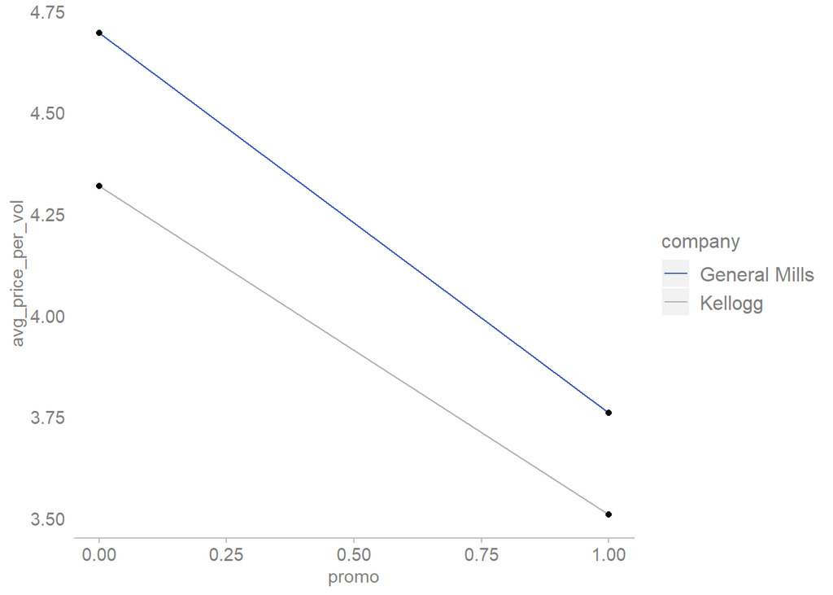

```r
full_df %>%
  filter(company != 'Post') %>%
  group_by(company, promo) %>%
  summarize(avg_price_per_vol = mean(price / volume)) %>%
  ggplot() +
  geom_line(mapping = aes(x = promo, y = avg_price_per_vol, color = company)) +
  scale_colour_manual(values = c('#385cb7', 'grey70'), labels = c('General Mills', 'Kellogg')) +
  geom_point(mapping = aes(x = promo, y = avg_price_per_vol)) +
  my_theme
```

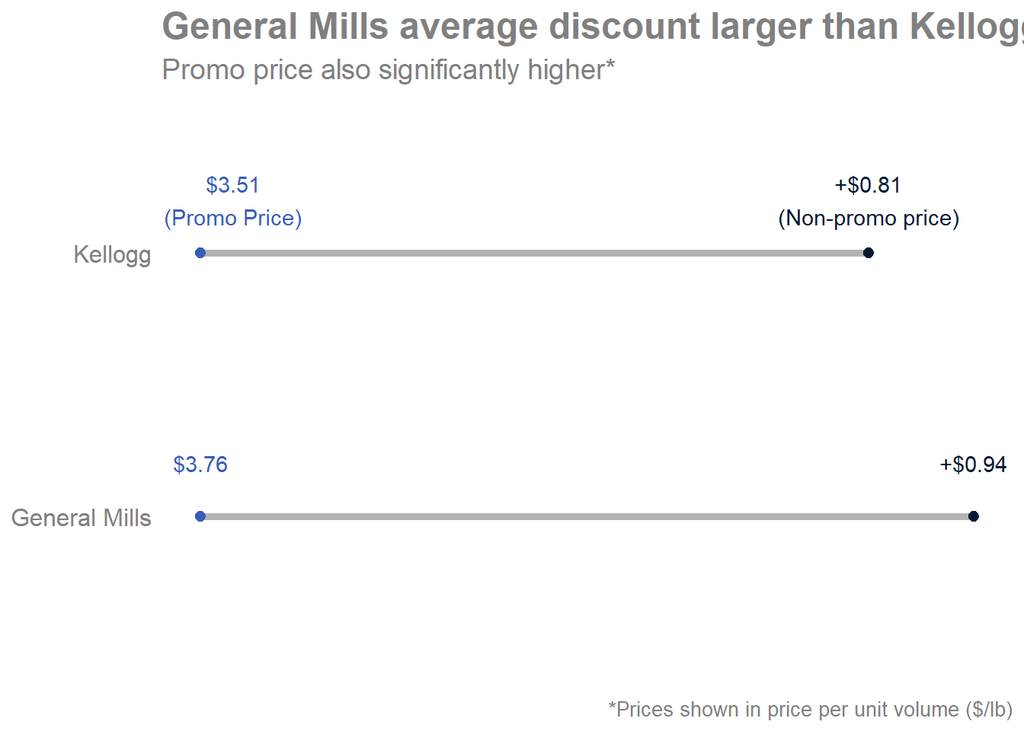

```r
full_df %>%
  filter(company != 'Post') %>%
  group_by(company, promo) %>%
  summarize(avg_price_per_vol = mean(price / volume)) %>%
  spread(promo, avg_price_per_vol, sep = '_') %>%
  ggplot() +
   geom_dumbbell(mapping = aes(y = company, x = c(0,0), xend = promo_0 - promo_1),
                 colour = 'grey70',
                 colour_x = '#385CB7',
                 colour_xend = '#001a33',
                 size = 1.75) +
  geom_text(mapping = aes(x = promo_0 - promo_1, y = c(1.2, 2.2)), label = c( '+$0.94','+$0.81\n(Non-promo price)'), color = '#001a33') +
  geom_text(mapping = aes(x = c(0,0.04), y = c(1.2, 2.2)), label = c('$3.76', '$3.51\n(Promo Price)'), color = '#385CB7') +
  labs(title = 'General Mills average discount larger than Kellogg',
       subtitle = 'Promo price also significantly higher*',
       caption = '*Prices shown in price per unit volume ($/lb)') +
  theme(panel.border = element_blank(),
        panel.background = element_blank(),
        axis.ticks.y = element_blank(),
        axis.line.x = element_blank(),
        axis.ticks.x = element_blank(),
        axis.title.x = element_blank(),
        axis.title.y = element_blank(),
        plot.title = element_text(color = "#808080", size = 18, face = "bold"),
        plot.subtitle = element_text(color = "#808080", size = 14, face = "plain"),
        axis.text.x = element_blank(),
        axis.text.y = element_text(color = "#808080", size = 12),
        axis.title = element_text(color = "#808080", size = 11, face = "plain"),
        legend.title = element_text(color = "#808080", size = 12, face = "plain"),
        legend.text = element_text(color = "#808080", size = 12, face = "plain"),
        plot.caption = element_text(color = "#808080", size = 10, face = "plain", margin = margin(t=10))
        )
```

Based on the hypothesis tests above, we see that not every General Mills brand sees a positive impact to their sales from promotions. Lucky Charms, Cocoa Puffs, and Cinnamon Toast Crunch see positive impacts to their sales that are both practically and statistically significant. Kix sees no statistically significant impact to its average sales, while Cheerios has a large negative impact that is also statistically significant.

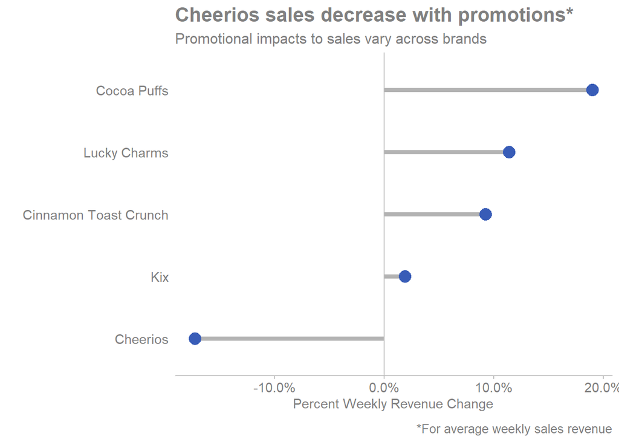

```r
# Create new object to make visualization easier
fig1 <- full_df %>%
  filter(company == "General Mills") %>%
  group_by(brand, promo) %>%
  summarise(avg_sales = mean(total_sales)) %>%
  pivot_wider(names_from = promo, values_from = avg_sales) %>%
  rename("no_promo" = "0", "promo" = "1") %>%
  mutate(difference = promo - no_promo,
         pdifference = (promo - no_promo)/promo)

# Lollipop visualization to highlight impacts of promotions to brands
ggplot(data = fig1, mapping = aes(x = reorder(brand, pdifference), y = pdifference)) +
  geom_lollipop(color = "grey70", size = 1.75, point.colour = "#385CB7") +
  my_theme +
  coord_flip() +
  geom_hline(yintercept = 0, color = "gray") +
  labs(title = "Cheerios sales decrease with promotions*",
       subtitle = "Promotional impacts to sales vary across brands",
       x = "",
       y = "Percent Weekly Revenue Change",
       caption = "*For average weekly sales revenue") +
  scale_y_continuous(labels = scales::percent) +
  scale_x_discrete(labels = c("GENERAL MILLS COCOA PUFFS" = "Cocoa Puffs", "GENERAL MILLS LUCKY CHARMS" = "Lucky Charms", "GENERAL MILLS CINNAMON TST CR" = "Cinnamon Toast Crunch", "GENERAL MILLS KIX" = "Kix", "GENERAL MILLS CHEERIOS" = "Cheerios"))
```

```r
# Save plot for memo
ggsave("figure1.png", width = 7.5, height = 5, units = "in")

# Try a column chart
# full_df %>%
#   filter(company == "General Mills") %>%
#   group_by(brand, promo) %>%
#   summarise(avg_sales = mean(total_sales)) %>%
#   ggplot(mapping = aes(x = brand, y = avg_sales, group = promo, fill = as.factor(promo))) +
#   geom_col(position = "dodge") +
#   coord_flip()
```

```r
# Save df for use in memo
write_csv(full_df, path = 'full_df.csv')
```